# Practice Lab 8

Sean Huvaya

2024-03-12

## Building the Dataset

Creating a simulated dataset called df. It has 649 rows, each representing a patient. The EGFR30 column is generated using the rbinom function, which generates binomially distributed random numbers with a probability of success (prevalence) of 0.177. The EGFR30 column is then converted to a categorical variable.

A new column, SUN_Diag, is introduced to the dataset and is initially filled with NA. The values for SUN_Diag are then generated using different probabilities based on the EGFR30 results. Finally, SUN_Diag is turned into a factor.

```r
df <- data.frame('PATIENT_ID' = 1:649, "EGFR30" = rbinom(649, 1, 0.177))
df$EGFR30 <- factor(df$EGFR30)

df$SUN_Diag <- NA
df$SUN_Diag[df$EGFR30 == 0] <- rbinom(length(df$EGFR30[df$EGFR30 == 0]), 1, (1 - 0.846))
df$SUN_Diag[df$EGFR30==1] <- rbinom(length(df$EGFR30[df$EGFR30==1]), 1, 0.661)
df$SUN_Diag <- factor(df$SUN_Diag)

df$SUN <- 1
df$SUN[df$SUN_Diag == 1] <- sample(2:6, replace = TRUE, size = length(df$SUN[df$SUN_Diag == 1]))
df$SUN<-factor(df$SUN)
```

## Defining TP, FP, TN and FN, and building them into factors

A new column. Diag_Cat is added to the dataset and initialized with NA values. Diagnostic classifications (TP, TN, FN, and FP) are assigned for conditions involving EGFR30 and SUN_Diag. Diag_Cat is then turned into a factor.

```r
df$Diag_Cat <- NA
df$Diag_Cat[df$EGFR30 == 1 & df$SUN_Diag == 1]<-"TP"
df$Diag_Cat[df$EGFR30 == 0 & df$SUN_Diag == 0]<-"TN"
df$Diag_Cat[df$EGFR30 == 1 & df$SUN_Diag == 0]<-"FN"
df$Diag_Cat[df$EGFR30 == 0 & df$SUN_Diag == 1]<-"FP"
df$Diag_Cat_Factor <- factor(df$Diag_Cat)
```

## Calculating sensitivity, specificity and predictive values.

This code calculates sensitivity (sens), specificity (spec), positive predictive value (PPV), and negative predictive value (NPV) based on the counts of the diagnostic categories.

```r
TP <- length(df$Diag_Cat_Factor[df$Diag_Cat_Factor=="TP"])
TP <- summary(df$Diag_Cat_Factor)[4]
sens <- as.numeric(summary(df$Diag_Cat_Factor)[4] / sum(summary(df$Diag_Cat_Factor)[c(1,4)]))
spec <- as.numeric(summary(df$Diag_Cat_Factor)[3] / sum(summary(df$Diag_Cat_Factor)[c(3,2)]))
PPV <- as.numeric(summary(df$Diag_Cat_Factor)[4] / sum(summary(df$Diag_Cat_Factor)[c(2,4)]))
NPV <- as.numeric(summary(df$Diag_Cat_Factor)[3] / sum(summary(df$Diag_Cat_Factor)[c(3,1)]))
```

## Building a ROC curve and providing the AUC with Cis.

This line creates the ROC curve with the roc() function from the pROC package. It uses EGFR30 == 1 as the actual class label (positive) and SUN as the predictor. Additional arguments are included for calculating the area under the curve (AUC), confidence intervals (CI), and plotting the curve.

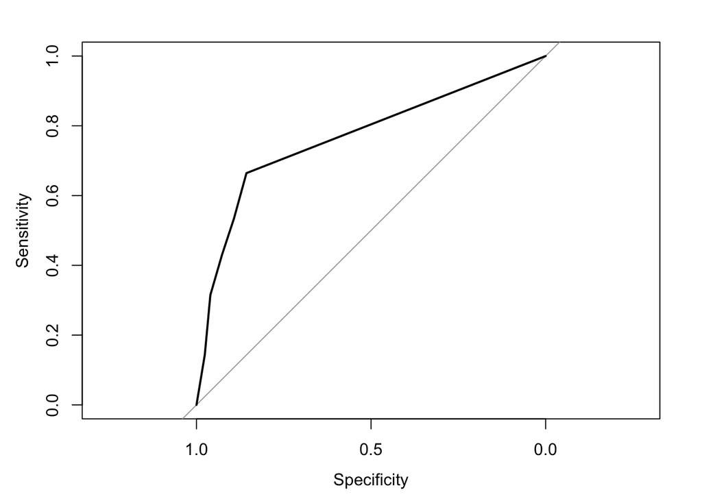

```
##
## Call:
## roc.default(response = df$EGFR30 == 1, predictor = as.numeric(df$SUN),     auc = TRUE, ci = TRUE, plot = TRUE)
##
## Data: as.numeric(df$SUN) in 503 controls (df$EGFR30 == 1 FALSE) < 146 cases (df$EGFR30 == 1 TRUE).
## Area under the curve: 0.7688
## 95% CI: 0.7264-0.8112 (DeLong)
```

```r
roc(df$EGFR30 == 1 , as.numeric(df$SUN), auc = TRUE, ci = TRUE, plot = TRUE)
```

## Repeating the exercise for the criterion eGFR<15 mL/min/1.73m^2

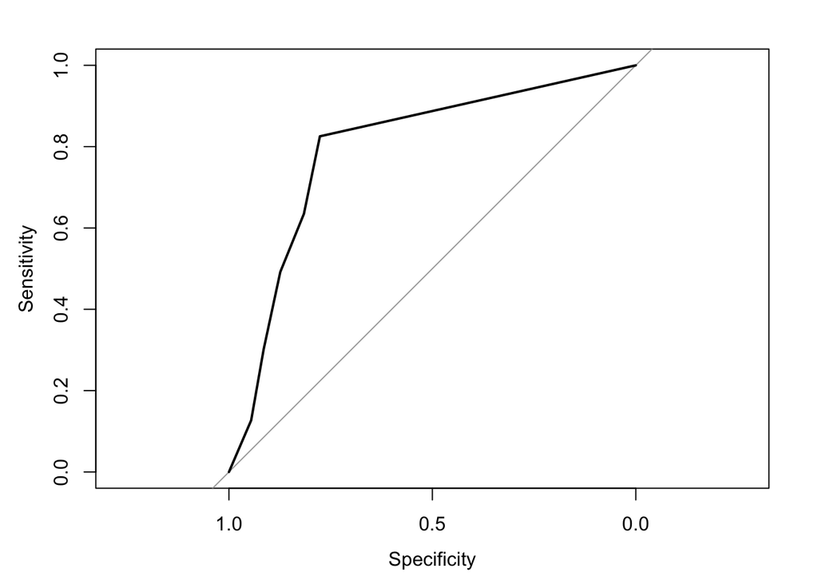

```
##
## Call:
## roc.default(response = df2$EGFR15 == 1, predictor = as.numeric(df2$SUN),     auc = TRUE, ci = TRUE, plot = TRUE)
##
## Data: as.numeric(df2$SUN) in 586 controls (df2$EGFR15 == 1 FALSE) < 63 cases (df2$EGFR15 == 1 TRUE).
## Area under the curve: 0.7963
## 95% CI: 0.7437-0.8489 (DeLong)
```

```r
# Simulating the Dataset
df2 <- data.frame('PATIENT_ID' = 1:649, "EGFR15" = rbinom(649, 1, 0.096))

# Converting EGFR15 to a factor
df2$EGFR15 <- factor(df2$EGFR15)

# Generating Sun_Diag using different probabilities based on the EGFR15 results
df2$SUN_Diag <- NA
df2$SUN_Diag[df2$EGFR15 == 0] <- rbinom(length(df2$EGFR15[df2$EGFR15 == 0]), 1, (1 - 0.818))
df2$SUN_Diag[df2$EGFR15 == 1] <- rbinom(length(df2$EGFR15[df2$EGFR15==1]), 1, 0.823)
df2$SUN_Diag <- factor(df2$SUN_Diag)

df2$SUN <- 1
df2$SUN[df2$SUN_Diag == 1] <- sample(2:6, replace = TRUE, size = length(df2$SUN[df2$SUN_Diag == 1]))
df2$SUN<-factor(df2$SUN)

# Assigning diagnostic classifications (TP, TN, FN, and FP) for conditions involving EGFR15 and SUN_Diag
df2$Diag_Cat <- NA
df2$Diag_Cat[df2$EGFR15 == 1 & df2$SUN_Diag == 1]<-"TP"
df2$Diag_Cat[df2$EGFR15 == 0 & df2$SUN_Diag == 0]<-"TN"
df2$Diag_Cat[df2$EGFR15 == 1 & df2$SUN_Diag == 0]<-"FN"
df2$Diag_Cat[df2$EGFR15 == 0 & df2$SUN_Diag == 1]<-"FP"
df2$Diag_Cat_Factor <- factor(df2$Diag_Cat)

# Calculating sensitivity, specificity and predictive values.
TP <- length(df2$Diag_Cat_Factor[df2$Diag_Cat_Factor=="TP"])
TP <- summary(df2$Diag_Cat_Factor)[4]
sens <- as.numeric(summary(df2$Diag_Cat_Factor)[4] / sum(summary(df2$Diag_Cat_Factor)[c(1,4)]))
spec <- as.numeric(summary(df2$Diag_Cat_Factor)[3] / sum(summary(df2$Diag_Cat_Factor)[c(3,2)]))
PPV <- as.numeric(summary(df2$Diag_Cat_Factor)[4] / sum(summary(df2$Diag_Cat_Factor)[c(2,4)]))
NPV <- as.numeric(summary(df2$Diag_Cat_Factor)[3] / sum(summary(df2$Diag_Cat_Factor)[c(3,1)]))

roc(df2$EGFR15 == 1 , as.numeric(df2$SUN), auc = TRUE, ci = TRUE, plot = TRUE)
```